# Assignment8

Jeff Moise

10/30/2019

1.Working with the Titanic dataset. Use the map function to compute the number of NA for each columns. Use map_int to turn the output to an interger vector.

```r
library(purrr)
library(readr)
df <- read_csv(file="C:\\Users\\student\\Documents\\R\\titanic.csv")
```

```r
map(df, ~sum(is.na(.)))
```

```
## $PassengerId
## [1] 0
##
## $Survived
## [1] 0
##
## $Pclass
## [1] 0
##
## $Name
## [1] 0
##
## $Sex
## [1] 0
##
## $Age
## [1] 177
##
## $SibSp
## [1] 0
##
## $Parch
## [1] 0
##
## $Ticket
## [1] 0
##
## $Fare
## [1] 0
##
## $Cabin
## [1] 687
##
## $Embarked
## [1] 2
```

```r
map_int(df,~sum(is.na(.)))
```

```
## PassengerId    Survived      Pclass        Name         Sex         Age
##           0           0           0           0           0         177
##       SibSp       Parch      Ticket        Fare       Cabin    Embarked
##           0           0           0           0         687           2
```

2. Use map function to calculate the mean of numeric variables in the Titanic dataset.

```r
library(dplyr)
```

```r
dfnum <- select_if(df, is.numeric)
map(dfnum, ~mean(., na.rm=TRUE))
```

```
## $PassengerId
## [1] 446
##
## $Survived
## [1] 0.3838384
##
## $Pclass
## [1] 2.308642
##
## $Age
## [1] 29.69912
##
## $SibSp
## [1] 0.5230079
##
## $Parch
## [1] 0.3815937
##
## $Fare
## [1] 32.20421
```

3. Use map function to show the means, medians, and standard deviations of numeric variables in the Titanic dataset. Use map_df to show the result in a data frame format.

```r
map_df(dfnum, function(x) c(mean(x,na.rm=TRUE), median(x,na.rm=TRUE), sd(x,na.rm=TRUE)))
```

```
## # A tibble: 3 x 7
##   PassengerId Survived Pclass   Age SibSp Parch  Fare
##         <dbl>    <dbl>  <dbl> <dbl> <dbl> <dbl> <dbl>
## 1        446     0.384  2.31   29.7 0.523 0.382  32.2
## 2        446     0      3      28   0     0      14.5
## 3        257.    0.487  0.836  14.5 1.10  0.806  49.7
```

4. Use map function to show the mode (most frequent category) and the number of categories for each categorical variables. Put the result in data frame.

```r
dfchar <- select_if(df, is.character)
head(dfchar)
```

```
## # A tibble: 6 x 5
##   Name                                   Sex   Ticket        Cabin Embarked
##   <chr>                                  <chr> <chr>         <chr> <chr>
## 1 Braund, Mr. Owen Harris                male  A/5 21171     <NA>  S
## 2 Cumings, Mrs. John Bradley (Florence ~ fema~ PC 17599      C85   C
## 3 Heikkinen, Miss. Laina                 fema~ STON/O2. 310~ <NA>  S
## 4 Futrelle, Mrs. Jacques Heath (Lily Ma~ fema~ 113803        C123  S
## 5 Allen, Mr. William Henry               male  373450        <NA>  S
## 6 Moran, Mr. James                       male  330877        <NA>  Q
```

```r
themode<- function(b) {
 z <- na.omit(unique(b))
 z1 <- tabulate(match(b, z))
 z[z1 == max(z1)][1] }

map_df(dfchar, function(b) {c(themode(b), nlevels(factor(b)))})
```

```
## # A tibble: 2 x 5
##   Name                    Sex   Ticket Cabin Embarked
##   <chr>                   <chr> <chr>  <chr> <chr>
## 1 Braund, Mr. Owen Harris male  347082 G6    S
## 2 891                     2     681    147   3
```

5. Use map to graph the histograms of numeric variables and bar charts of categorical variables in the Titanic data

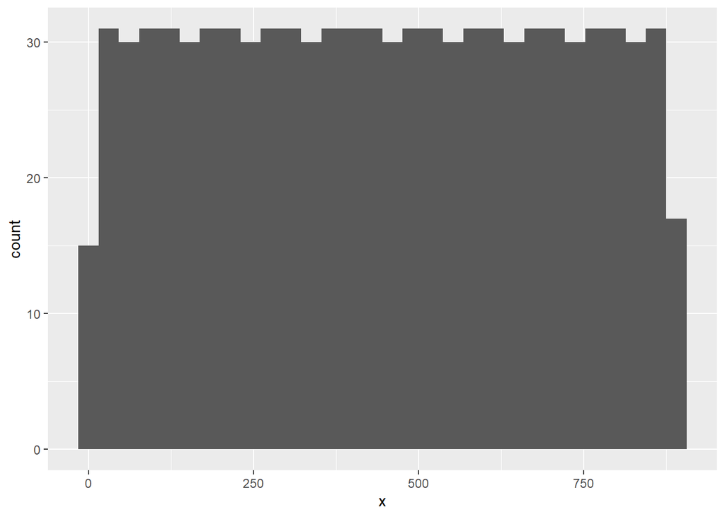

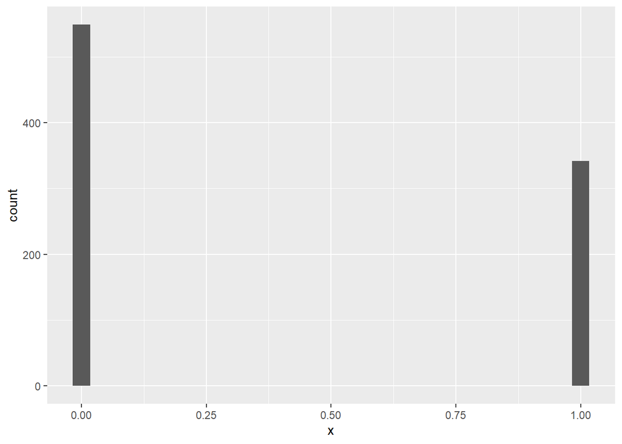

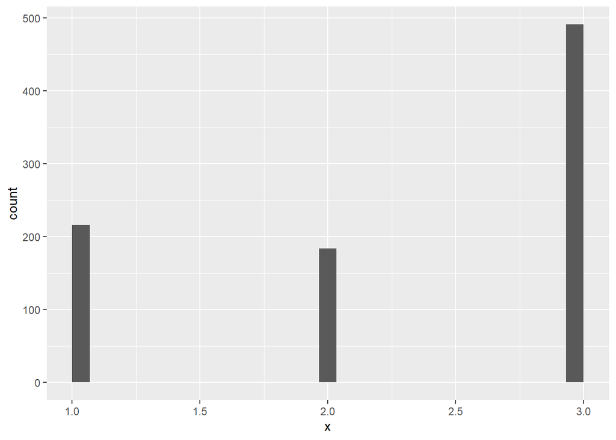

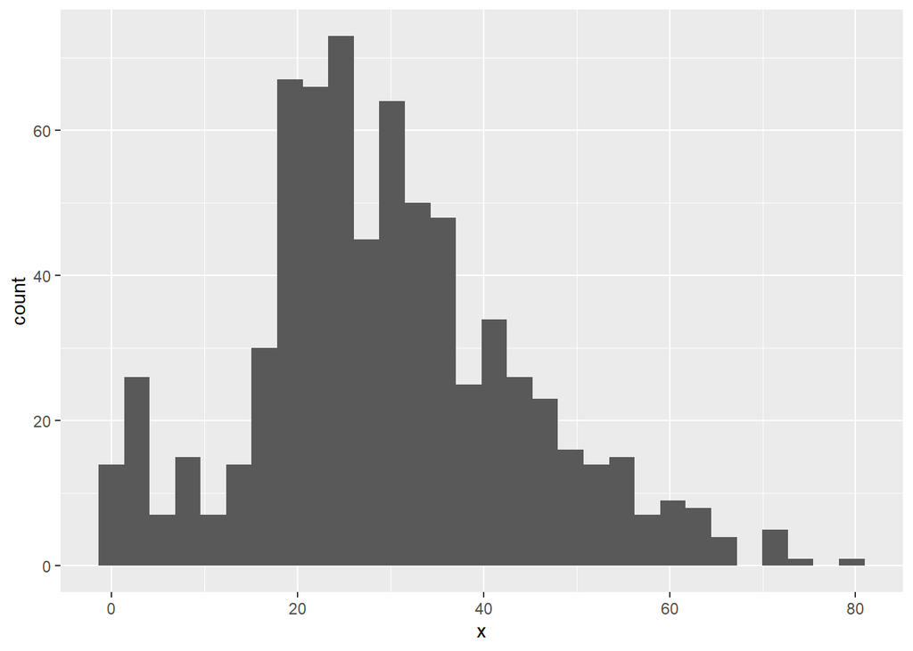

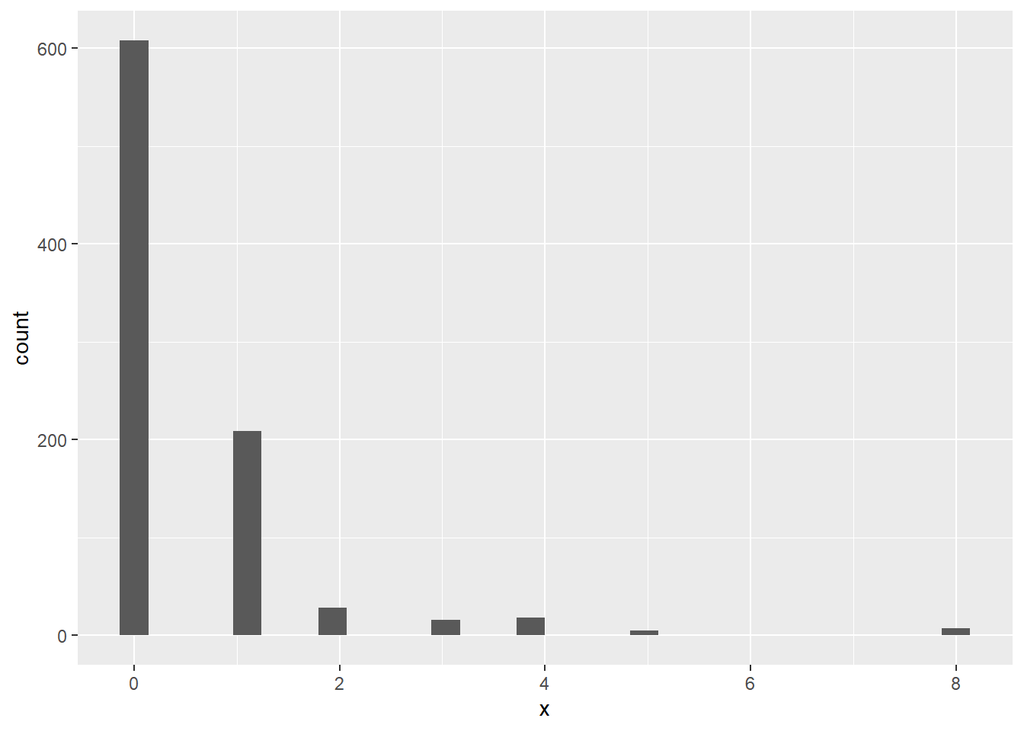

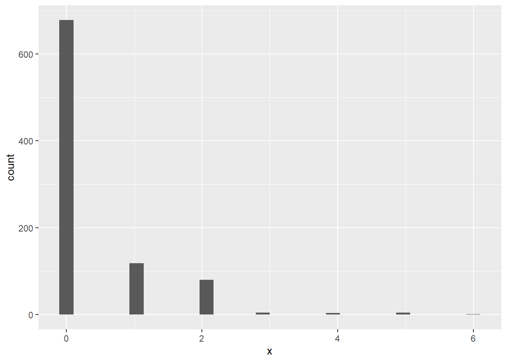

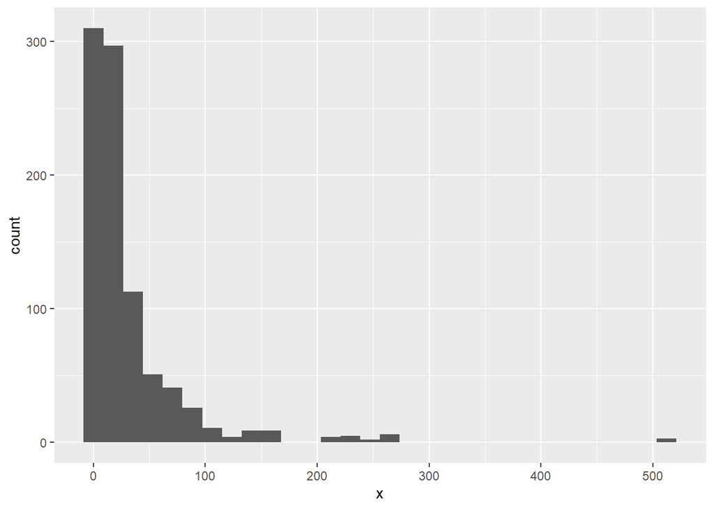

```r
library(ggplot2)
dfnum <- df %>%
  select_if(is.numeric)
dfcat<- df %>%
  select_if(is.character) %>%  select(-c(Name))

map(dfnum, function(x) {ggplot(dfnum,aes(x))+
    geom_histogram()})
```

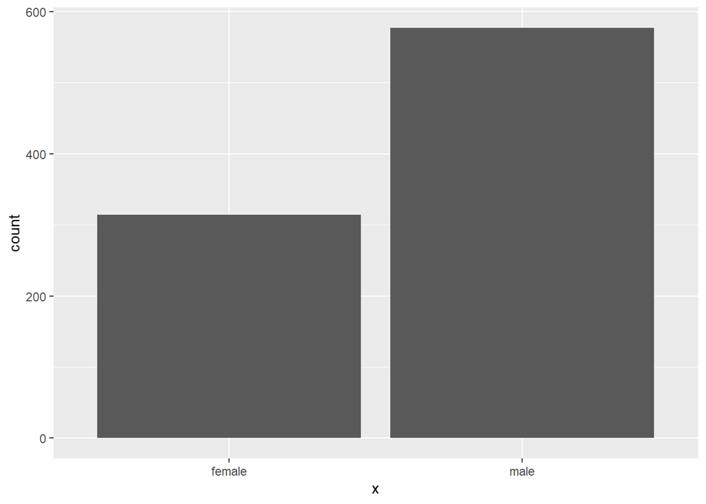

[figure not shown]

[figure not shown]

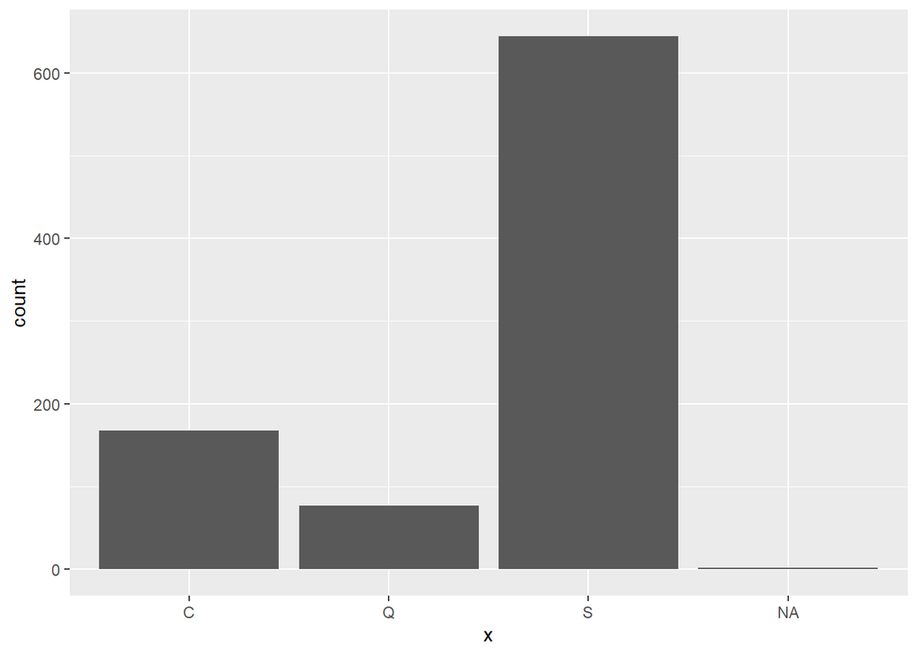

```r
map(dfcat, function(x){ggplot(dfcat, aes(x)) +geom_bar()})
```

```r
# I was unable to complete 11 on Assignment 7
```

Write a function, using map, to

input: a data frame

output: a data frame of consist three columns x1, x2 and r where the pairs (x1,x2) are all possible pairs of continuous variables of the input data frame and r is the corresponding r square of x1 and x2. Test the function on the titanic data assuming that the PassengerID is also a coninuous variable.